# Lab 4: Spatial Predictive Analysis

Analyzing 311 Violations

Author

Mackenna Amole

Published

April 9, 2026

## Assignment Overview

In this lab, I applied spatial predictive modeling techniques demonstrated in an in-class exercise using 311 Sanitation Violations as the predictor variable. I built a complete spatial predictive model, documented my process, and interpreted my results.

### Learning Objectives

- Adapt example code to analyze a new dataset
- Build spatial features for predictive modeling
- Apply count regression techniques to spatial data
- Implement spatial cross-validation
- Interpret and communicate model results
- Critically evaluate model performance

## Choosing My 311 Violation Type

### Getting the Data

Visit the Chicago 311 Service Requests dataset:

https://data.cityofchicago.org/stories/s/311-Dataset-Changes-12-11-2018/d7nq-5g7t

Selection: **SANITATION VIOLAITONS** Sanitation 311 violations were selected because they reflect neighborhood-level environmental quality issues that are likely to exhibit spatial clustering. These violations are not randomly distributed and may be influenced by built environment conditions, reporting behavior, and population density. The goal of this analysis is to model spatial variation in sanitation complaints using spatial features and count regression models. The results are evaluated using spatial validation techniques to assess predictive performance across Chicago.

## Completing the Analysis

```r
#install - comment out later
# install.packages("spatstat.explore")
# install.packages("spatstat.geom")
# install.packages("viridis")

# Load required packages
library(tidyverse)
library(sf)
library(here)
library(viridis)
library(terra)
library(spdep)
library(FNN)
library(MASS)
library(patchwork)
library(knitr)
library(kableExtra)
library(classInt)
# Spatstat for analyzing point patterns - split into sub-packages
library(spatstat.geom)
library(spatstat.explore)


# Set options
options(scipen = 999)  # No scientific notation
set.seed(5080)         # Reproducibility, could be any number

# Create consistent theme for visualizations
theme_crime <- function(base_size = 11) {
  theme_minimal(base_size = base_size) +
    theme(
      plot.title = element_text(face = "bold", size = base_size + 1),
      plot.subtitle = element_text(color = "gray30", size = base_size - 1),
      legend.position = "right",
      panel.grid.minor = element_blank(),
      axis.text = element_blank(),
      axis.title = element_blank()
    )
}

# Set as default
theme_set(theme_crime())

cat("✓ All packages loaded successfully!\n")
cat("✓ Working directory:", getwd(), "\n")
```

#### 1: Data Loading & Exploration

- 1.1: Load 311 data and Chicago spatial boundaries

I loaded Chicago’s 311 Sanitation Violations dataset and the spatial boundary files for Chicago, its police districts and its police beats. I projected them all into a consistent coordinate reference system (ESRI:102271) to ensure spatial alignment. This step is essential because spatial analysis requires all datasets to exist in the same projection system. Otherwise the frame of reference is skewed and spatial data may be misaligned. After loading and transforming the data, I confirmed that the sanitation dataset contains a large number of valid spatial points (152636) distributed across the city.

```r
# Load police districts (used for spatial cross-validation)
policeDistricts <- st_read("https://data.cityofchicago.org/api/geospatial/24zt-jpfn?method=export&format=GeoJSON") %>% st_transform('ESRI:102271') %>% dplyr::select(District = dist_num)
# Load police beats (smaller administrative units)
policeBeats <-
  st_read("https://data.cityofchicago.org/api/geospatial/n9it-hstw?method=export&format=GeoJSON") %>%
  st_transform('ESRI:102271') %>%
  dplyr::select(Beat = beat_num)
# Load Chicago boundary
chicagoBoundary <-
  st_read("https://raw.githubusercontent.com/urbanSpatial/Public-Policy-Analytics-Landing/master/DATA/Chapter5/chicagoBoundary.geojson") %>%
  st_transform('ESRI:102271')
cat("✓ Loaded spatial boundaries\n")
```

```
✓ Loaded spatial boundaries
```

```r
cat("  - Police districts:", nrow(policeDistricts), "\n")
```

```
  - Police districts: 25
```

```r
cat("  - Police beats:", nrow(policeBeats), "\n")
```

```
  - Police beats: 277
```

```r
sanitation <- read_csv(here("labs/lab_4//311_Sanitation.csv")) %>%
  filter(!is.na(Longitude), !is.na(Latitude)) %>%
  st_as_sf(coords = c("Longitude", "Latitude"), crs = 4326) %>%
  st_transform('ESRI:102271')

glimpse(sanitation)
```

```
Rows: 152,636
Columns: 15
$ `Creation Date`                              <chr> "12/18/2018", "12/18/2018…
$ Status                                       <chr> "Open", "Open", "Open - D…
$ `Completion Date`                            <chr> NA, NA, NA, "12/18/2018",…
$ `Service Request Number`                     <chr> "18-03387752", "18-033886…
$ `Type of Service Request`                    <chr> "Sanitation Code Violatio…
$ `What is the Nature of this Code Violation?` <chr> "Other", "Other", "Dumpst…
$ `Street Address`                             <chr> "5706 S NARRAGANSETT AVE"…
$ `ZIP Code`                                   <dbl> 60638, 60651, 60628, 6064…
$ `X Coordinate`                               <dbl> 1134696, 1141443, 1173296…
$ `Y Coordinate`                               <dbl> 1866027, 1908946, 1831190…
$ Ward                                         <dbl> 13, 37, 34, 5, 22, 33, 6,…
$ `Police District`                            <dbl> 8, 25, 22, 3, 10, 17, 6, …
$ `Community Area`                             <dbl> 56, 25, 49, 43, 30, 16, 6…
$ Location                                     <chr> "(41.788565462039, -87.78…
$ geometry                                     <POINT [m]> POINT (345856.4 568…
```

```r
cat("Number of sanitation requests:", nrow(sanitation), "\n")
```

```
Number of sanitation requests: 152636
```

```r
# Basic summary stats of raw 311 data

cat("Summary of Sanitation 311 Data:\n")
```

```
Summary of Sanitation 311 Data:
```

```r
# Total observations
cat("Total requests:", nrow(sanitation), "\n\n")
```

```
Total requests: 152636
```

```r
# Since it's point data, we summarize spatial + temporal fields if available
summary(st_coordinates(sanitation))
```

```
       X                Y
 Min.   :335540   Min.   :552962
 1st Qu.:351212   1st Qu.:566065
 Median :354631   Median :576405
 Mean   :354463   Mean   :575299
 3rd Qu.:357467   3rd Qu.:584176
 Max.   :367320   Max.   :594815
```

```r
# If your dataset has dates (VERY likely)
if ("Creation Date" %in% names(sanitation)) {
  cat("\nDate range:\n")
  print(range(sanitation$`Creation Date`, na.rm = TRUE))
}
```

```
Date range:
[1] "01/01/2011" "12/31/2017"
```

- 1.2: Create visualizations showing the spatial distribution of violation type

I created visualizations of the locations of sanitation violations and also created a kernel density estimation surface to visualize clustering/distribution. This step provides an initial understanding of spatial patterns before modeling/experimenting with interactions. These visuals allow us to identify clustering patterns and potential spatial dependence. The violations do not appear to be evenly distributed across Chicago. Instead, they are highly clustered in specific geographic areas. The KDE visual shows where the concentrations of sanitation violations are.

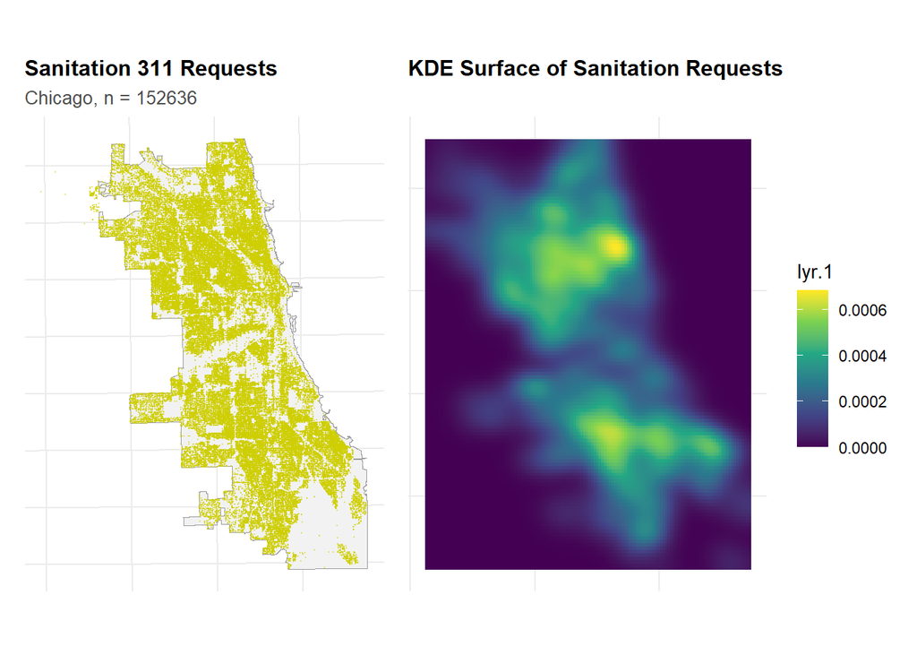

```r
# Point map
p1 <- ggplot() +
  geom_sf(data = chicagoBoundary, fill = "gray95", color = "gray60") +
  geom_sf(data = sanitation, color = "yellow3", size = 0.1, alpha = 0.4) +
  labs(
    title = "Sanitation 311 Requests",
    subtitle = paste0("Chicago, n = ", nrow(sanitation))
  )

# KDE surface
sanitation_ppp <- as.ppp(
  st_coordinates(sanitation),
  W = as.owin(st_bbox(chicagoBoundary))
)

kde_sanitation <- density.ppp(sanitation_ppp, sigma = 1000, edge = TRUE)
kde_raster <- rast(kde_sanitation)

# Convert to dataframe for plotting
kde_df <- as.data.frame(kde_raster, xy = TRUE)
names(kde_df)
p2 <- ggplot(kde_df) +
  geom_raster(aes(x = x, y = y, fill = lyr.1)) +
  scale_fill_viridis_c() +
  labs(title = "KDE Surface of Sanitation Requests")

p1 + p2
```

- 1.3: Describe patterns observed

The sanitation violations have strong spatial clustering. The areas of higher concentrations may be more densely populated or higher activity parts of the city. The KDE surface confirms that these violations do not follow random dispersion, which may be the result of external factors like population density or cycles of reporting/policing/confirming.

#### 2: Fishnet Grid Creation

- 2.1: Create a 500m x 500m fishnet grid
- 2.2: Aggregate your violations to grid cells
- 2.3: Visualize the count distribution

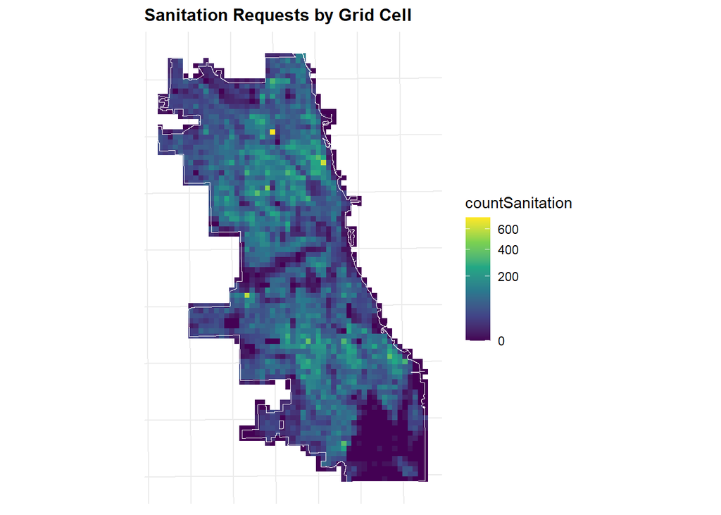

```r
# 2.1 Create fishnet
fishnet <- st_make_grid(chicagoBoundary, cellsize = 500, square = TRUE) %>%
  st_sf() %>%
  mutate(uniqueID = row_number()) %>%
  st_transform('ESRI:102271')

fishnet <- fishnet[chicagoBoundary, ]

# 2.2 Aggregate sanitation
sanitation_fishnet <- st_join(sanitation, fishnet, join = st_within) %>%
  st_drop_geometry() %>%
  group_by(uniqueID) %>%
  summarize(countSanitation = n())

# Join back
fishnet <- fishnet %>%
  left_join(sanitation_fishnet, by = "uniqueID") %>%
  mutate(countSanitation = replace_na(countSanitation, 0))

# 2.3 Map
ggplot() +
  geom_sf(data = fishnet, aes(fill = countSanitation), color = NA) +
  geom_sf(data = chicagoBoundary, fill = NA, color = "white") +
  scale_fill_viridis_c(trans = "sqrt") +
  labs(title = "Sanitation Requests by Grid Cell")
```

```r
summary(fishnet$countSanitation)
```

```
   Min. 1st Qu.  Median    Mean 3rd Qu.    Max.
   0.00   10.00   46.00   62.02   93.00  727.00
```

```r
cat("\nMean:", mean(fishnet$countSanitation))
```

```
Mean: 62.02034
```

```r
cat("\nSD:", sd(fishnet$countSanitation))
```

```
SD: 65.22424
```

```r
cat("\nRange:", range(fishnet$countSanitation))
```

```
Range: 0 727
```

#### 3: Spatial Features

- 3.1: Calculate k-nearest neighbor features - The k-nearest neighbor function calculates the 3 nearest sanitation violations to each cell of the fishnet. A cell with a smaller distance to its nearest violations may be worse affected.
- 3.2: Perform Local Moran’s I analysis - The local Moran’s I analysis helps to identify clusters in the data, and whether high/low values are spatially clustered. The hotspots are identified as places where high-high values are surrounded by other high-high values, demonstrating clustering and not random distribution.
- 3.3: Identify hot spots and cold spots - The hot (high-high) and cold (low-low) spots are based on the Moran’s I clustering (above).
- 3.4: Create distance-to-hotspot measures - The distance of cells (centroids) to the hotspots (centroids) is calculated in this step. These distances are important because shorter distances (aka closer proximity to hotspots) are likely to face similar challenges due to the clustering.
- 3.5: Join any additional contextual data if you are looking for more to do and really get into this (e.g., demographics, land use) - Added police districts

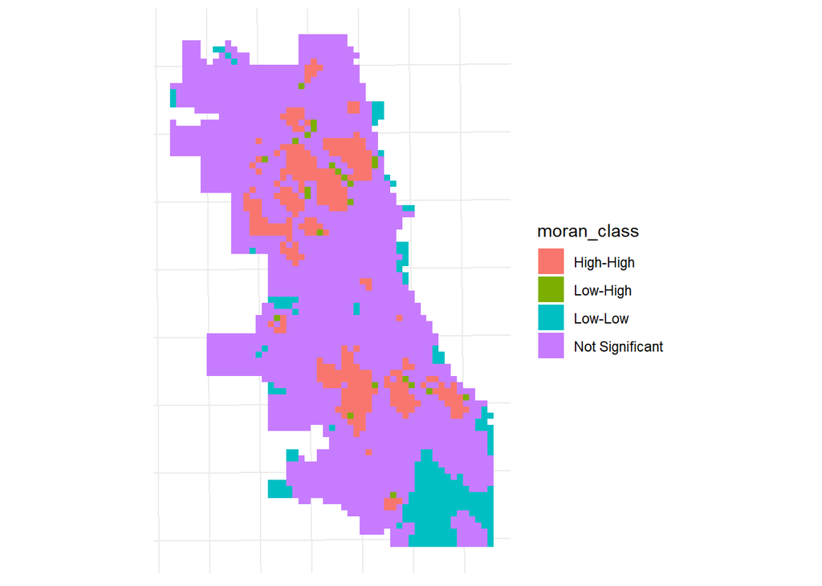

```r
# 3.1 KNN
fishnet_coords <- st_coordinates(st_centroid(fishnet))
sanitation_coords <- st_coordinates(sanitation)

nn <- get.knnx(sanitation_coords, fishnet_coords, k = 3)

fishnet <- fishnet %>%
  mutate(sanitation.nn = rowMeans(nn$nn.dist))

# 3.2 Moran's I
coords <- st_coordinates(st_centroid(fishnet))
neighbors <- spdep::knn2nb(spdep::knearneigh(coords, k = 5))
weights <- spdep::nb2listw(neighbors, style = "W")

local_moran <- spdep::localmoran(fishnet$countSanitation, weights)

fishnet <- fishnet %>%
  mutate(
    local_i = local_moran[,1],
    p_value = local_moran[,5],
    moran_class = case_when(
      p_value > 0.05 ~ "Not Significant",
      local_i > 0 & countSanitation > mean(countSanitation) ~ "High-High",
      local_i > 0 ~ "Low-Low",
      local_i < 0 & countSanitation > mean(countSanitation) ~ "High-Low",
      TRUE ~ "Low-High"
    )
  )

# 3.3 Map clusters
ggplot() +
  geom_sf(aes(fill = moran_class), data = fishnet, color = NA)
```

```r
# 3.4 Distance to hotspots
hotspots <- fishnet %>% filter(moran_class == "High-High")

fishnet <- fishnet %>%
  mutate(
    dist_to_hotspot = as.numeric(
      st_distance(st_centroid(fishnet), st_union(st_centroid(hotspots)))
    )
  )

# 3.5 Join districts
fishnet <- st_join(fishnet, policeDistricts) %>%
  filter(!is.na(District))
```

#### 4: Count Regression Models

- 4.1: Fit Poisson regression
- 4.2: Fit Negative Binomial regression
- 4.3: Compare model fit (AIC)

```r
fishnet_model <- fishnet %>%
  st_drop_geometry() %>%
  dplyr::select(
    countSanitation,
    sanitation.nn,
    dist_to_hotspot
  ) %>%
  mutate(
    countSanitation = as.numeric(countSanitation),
    sanitation.nn = as.numeric(sanitation.nn),
    dist_to_hotspot = as.numeric(dist_to_hotspot)
  ) %>%
  filter(
    is.finite(countSanitation),
    is.finite(sanitation.nn),
    is.finite(dist_to_hotspot)
  )

# sanity check
cat("Missing values check:\n")
print(sapply(fishnet_model, function(x) sum(!is.finite(x))))

cat("\nSD check:\n")
print(sapply(fishnet_model, sd))

model_poisson <- glm(
  countSanitation ~ sanitation.nn + dist_to_hotspot,
  data = fishnet_model,
  family = poisson()
)

summary(model_poisson)

dispersion <- sum(residuals(model_poisson, type = "pearson")^2) /
  model_poisson$df.residual

cat("\nDispersion parameter:", dispersion, "\n")

if (dispersion > 1.5) {
  cat("⚠ Overdispersion detected → trying Negative Binomial\n")
} else {
  cat("✓ Poisson is likely sufficient\n")
}

model_nb <- tryCatch(
  MASS::glm.nb(
    countSanitation ~ sanitation.nn + dist_to_hotspot,
    data = fishnet_model
  ),
  error = function(e) {
    cat("\n❌ Negative Binomial failed:\n")
    print(e$message)
    return(NULL)
  }
)

if (!is.null(model_nb)) {
  cat("\nMODEL COMPARISON\n")
  cat("Poisson AIC:", AIC(model_poisson), "\n")
  cat("NB AIC:", AIC(model_nb), "\n")
}
```

[output not shown]

```r
# Summary statistics
summary(fishnet_model$countSanitation)
```

```
   Min. 1st Qu.  Median    Mean 3rd Qu.    Max.
   0.00   11.00   46.00   62.53   93.00  727.00
```

```r
mean(fishnet_model$countSanitation)
```

```
[1] 62.53338
```

```r
sd(fishnet_model$countSanitation)
```

```
[1] 65.82284
```

```r
range(fishnet_model$countSanitation)
```

```
[1]   0 727
```